# Wrangling Advance: Build Pipeline

Yi Yin

10/16/2018

# Scope

- Build pipeline on World Bank data set
- Explore the relationship between infant mortality and GPD per capita over time
- Group data by region/country to compare with the overall regression

# Cleaning

## Slice and Rename

Use the [`WDI` package](https://cran.r-project.org/web/packages/WDI/WDI.pdf) to obtain country-year data on infant mortality and GDP per capita from the World Bank database.

The indicator short names in the World Development Indicators are:

- `NY.GDP.PCAP.PP.KD` - GDP per capita, PPP (constant 2005 international)
- `SP.DYN.IMRT.IN` - Mortality rate, infant (per 1,000 live births)

Rename two variables to readable name: infant mortality (`infmort`) and GPD per capita (`gdpcap`).

```r
library(WDI)
wdi <- WDI(country = "all",
    indicator = c("NY.GDP.PCAP.PP.KD", "SP.DYN.IMRT.IN"),
    start = 1960,
    end = 2017,
    extra=TRUE)

dat<-wdi%>%dplyr::rename(gdpcap = NY.GDP.PCAP.PP.KD,
                    infmort = SP.DYN.IMRT.IN)%>%
        dplyr::filter(longitude != "", latitude != "")
```

## Sorting

Present a list of countries with the 5 highest and the 5 lowest infant mortality rates in 2017 along with their GDP per capita in that year.

```r
# 5 highest
dat%>%filter(year == 2017)%>%
        arrange(desc(infmort))%>%
        filter(between(row_number(), 1, 5))%>%
        select(country, infmort, gdpcap)%>%
        # and 5 lowest
        dplyr::full_join(dat%>%filter(year == 2017)%>%
        arrange(infmort)%>%
        filter(between(row_number(), 1, 5))%>%
        select(country, infmort, gdpcap))
```

```
##                     country infmort     gdpcap
## 1              Sierra Leone    85.9  1642.6066
## 2  Central African Republic    85.5   912.8021
## 3                   Somalia    78.2         NA
## 4                   Nigeria    77.3  5190.3544
## 5                      Chad    72.6  1587.0311
## 6                San Marino     1.6 58867.0134
## 7                   Iceland     1.7 55274.1891
## 8                  Slovenia     1.8 36622.1953
## 9                     Japan     1.9 41093.5006
## 10                   Cyprus     2.0 37766.9017
```

## Overall Regression

Run an overall regression predicting infant mortality from GDP per capita. I find a significant negetive association between infant mortality and GDP per capita

```r
summary(lm(infmort ~ gdpcap, data = dat))$coefficients
```

```
##                  Estimate   Std. Error   t value Pr(>|t|)
## (Intercept) 49.4261491529 4.803849e-01 102.88864        0
## gdpcap      -0.0009537491 1.932314e-05 -49.35788        0
```

### Scatter Plot

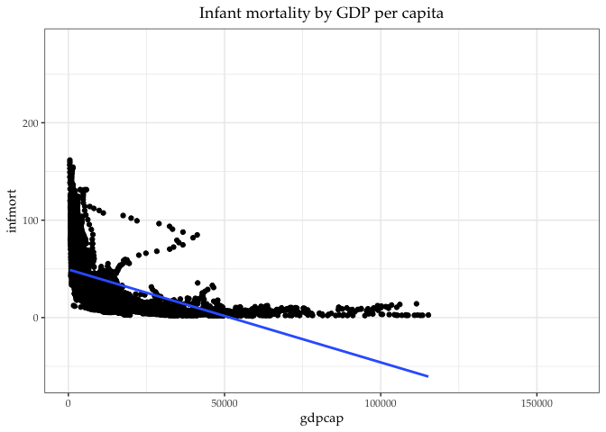

```r
library(ggplot2)
dat%>%select(infmort, gdpcap)%>%
       ggplot(aes(gdpcap, infmort))+
        geom_point()+
        geom_smooth(method = lm, se = FALSE)+
        ggtitle('Infant mortality by GDP per capita')+
        theme_bw(base_size = 11, base_family = "Palatino")+
        theme(plot.title = element_text(hjust = 0.5))
```

## Regression by Region

Let’s see if the overall relationship holds within world regions.

Split the the data by region and create a nested list that contains these split data frames.

Build a single pipeline, re-estimate the regression for each of these data frames, obtain the coefficient estimates for the slope for each region and present them in a table (sorted by size of the coefficient).

```r
dat%>%split(dat$region)%>%
        map(possibly(~ lm(infmort ~ gdpcap, data = .),
                     otherwise = NA_real_))%>%
        discard(is.na(.) == T) %>%
        map(~ coef(.))%>%
        map_dbl("gdpcap") %>%
        tibble(region = attr(., "names"),
               coef = .)%>%
        arrange(coef)
```

```
## # A tibble: 7 x 2
##   region                            coef
##   <chr>                            <dbl>
## 1 South Asia                 -0.00428
## 2 Sub-Saharan Africa         -0.00239
## 3 Latin America & Caribbean  -0.00102
## 4 East Asia & Pacific        -0.000659
## 5 Europe & Central Asia      -0.000443
## 6 Middle East & North Africa -0.000288
## 7 North America              -0.00000152
```

## Regression by Country

Let’s also check if the relationship is consistent if estimated within countries. Split the overall data by country and create a nested list that contains these split data frames. Again, estimate a simple linear regression, predicting infant mortality by GDP per capita.

```r
# extract slope p-value for 95% confidence level
pvalue <- dat%>%split(dat$country)%>%
        map(possibly(~ lm(infmort ~ gdpcap, data = .),
                     otherwise = NA_real_))%>%
        discard(is.na(.) == T) %>%
        map(summary)%>%map_dbl(possibly(
                        ~ .$coefficients['gdpcap', 'Pr(>|t|)'],
                         otherwise = NA_real_))
```

```r
dat%>%split(dat$country)%>%
        map(possibly(~ lm(infmort ~ gdpcap, data = .),
                     otherwise = NA_real_))%>%
        discard(is.na(.) == T) %>%
        map(summary)%>%map_dbl(possibly(
                        ~ .$coefficients['gdpcap', 'Estimate'],
                         otherwise = NA_real_))%>%
        tibble(country = attr(., "names"),
                  coef = .)%>%cbind(pvalue)%>%
        filter(pvalue < 0.05)%>%
        mutate(pos_slope = ifelse(coef >0, T, F))%>%
        group_by(pos_slope)%>%summarise(n = n())%>%
        mutate(percent = n/sum(n)* 100)
```

```
## # A tibble: 2 x 3
##   pos_slope     n percent
##   <lgl>     <int>   <dbl>
## 1 FALSE       152   94.4
## 2 TRUE          9    5.59
```

### Histogram of the Slope Coefficients

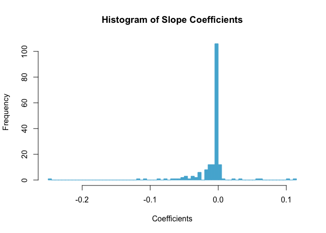

```r
dat%>%split(dat$country)%>%
        map(safely(~ lm(infmort ~ gdpcap, data = .)))%>%
        transpose()%>%pluck("result")%>%discard(is.null)%>%
        map(~ coef(.))%>%
        map_dbl("gdpcap")%>%hist(breaks = 100,
                                 col = "#53B2D6",
                                 border = '#53B2D6',
                                 xlab = "Coefficients",
                                 main = "Histogram of Slope Coefficients")
```

With regard to the absolute value difference, `Malawi` are most at odds with the overall regression estimated.

```r
dat%>%split(dat$country)%>%
        map(possibly(~ lm(infmort ~ gdpcap, data = .),
                     otherwise = NA_real_))%>%
        discard(is.na(.) == T) %>%
        map(summary)%>%
        map_dbl(possibly(
                        ~ .$coefficients['gdpcap', 'Estimate'],
                         otherwise = NA_real_))%>%
        tibble(country = attr(., "names"),
                  coef = .)%>%cbind(pvalue)%>%
        mutate(diff = abs(coef - (-0.0009353066)))%>%
        arrange(desc(diff))%>%filter(row_number() == 1)
```

```
##   country       coef       pvalue     diff
## 1  Malawi -0.2468663 7.781603e-10 0.245931
```

With regard to the largest positive slope, `Madagascar` are most at odds with the overall regression estimated.

```r
dat%>%split(dat$country)%>%
        map(possibly(~ lm(infmort ~ gdpcap, data = .),
                     otherwise = NA_real_))%>%
        discard(is.na(.) == T) %>%
        map(summary)%>%map_dbl(possibly(
                        ~ .$coefficients['gdpcap', 'Estimate'],
                         otherwise = NA_real_))%>%
        tibble(country = attr(., "names"),
                  coef = .)%>%cbind(pvalue)%>%
        arrange(desc(coef))%>%filter(row_number() == 1)
```

```
##      country      coef     pvalue
## 1 Madagascar 0.1106776 0.01087065
```

## Added Squared Term

Estimate regressions of infant mortality on GDP per capita and the square of GDP per capita. Compare the adjusted R-Squareds of the models with and without the added squared term of GDP per capita.

### Without the Added Squared Term

```r
dat%>%split(dat$country)%>%
        map(safely(~ lm(infmort ~ gdpcap, data = .)))%>%
        transpose()%>%pluck("result")%>%discard(is.null)%>%
         map(summary) %>% map_dbl("adj.r.squared")%>%mean()
```

```
## [1] 0.6611951
```

### With the Added Squared Term

```r
dat%>%split(dat$country)%>%
        map(safely(~ lm(infmort ~ I(gdpcap^2)+ gdpcap, data = .)))%>%
        transpose()%>%pluck("result")%>%discard(is.null)%>%
         map(summary) %>% map_dbl("adj.r.squared")%>%mean()
```

```
## [1] 0.7509739
```

I recommend to keep the squared term since the average model adjusted R-squared with the squared term is larger than the without counterpart.